# Analiza Spektralna - badanie średnich anomalii temperatury na świecie od 1945 roku

Justyna Zbiegień

03-02-2020

Dane użyte w projekcie pochodzą ze strony internetowej: www.ncdc.noaa.gov. Dane przedstawiają średnie miesieczne anomalie temperatury na całym świecie od roku 1945 do 2019. Ściągnięto plik .csv i obrobiono do dalszych analiz.

Najpierw zainstalowano niezbędne pakiety:

```r
#install.packages("oce")
#install.packages("outliers",repos="http://cran.rstudio.com/")
#install.packages("multitaper")
#install.packages("lattice")

library(oce)
library(outliers)
library(lattice)
library(multitaper)
require(multitaper)
```

Następnie wczytano dane:

```r
rm(list=ls())
dane<-read.table("anomalie2.csv",header=FALSE,sep="")
dane2 <- ts(read.table("anomalie2.csv"),start=1945,frequency=12)
```

## Wykres danych:

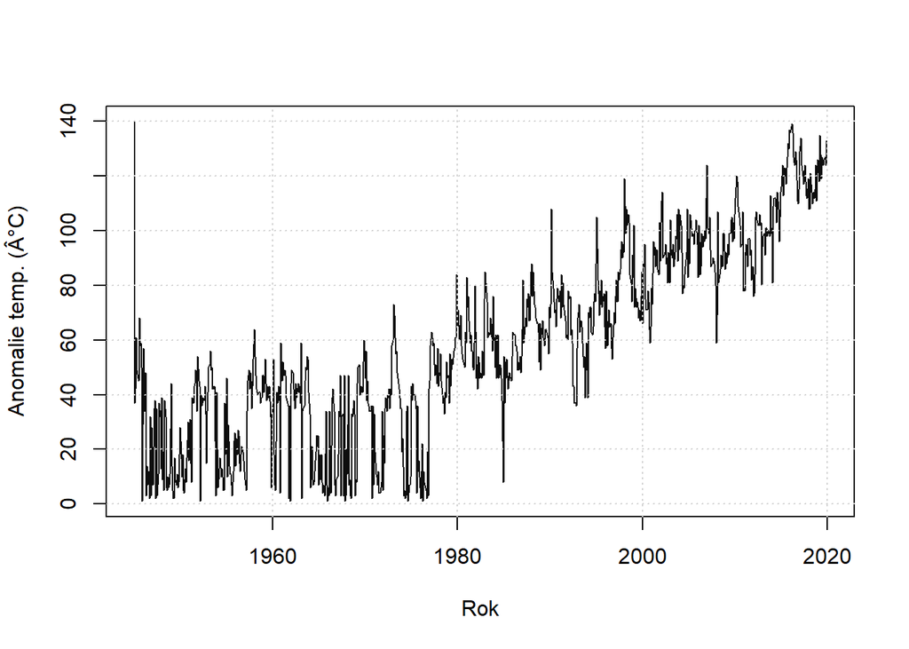

```r
#WYKRES:
plot(dane2, type="l", ylab="Anomalie temp. (°C)",xlab="Rok",col=grey(.05))
grid()
```

## Dekompozycja szeregu czasowego i usuwanie trendu z danych:

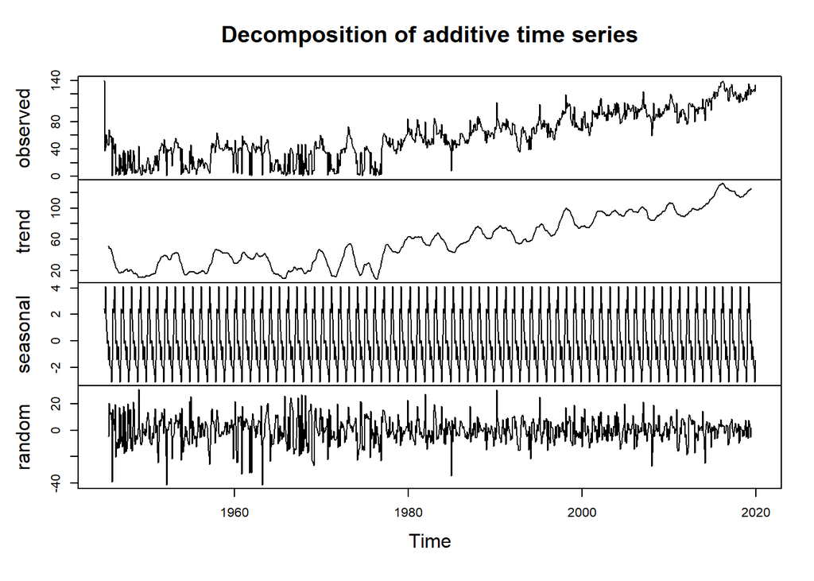

```r
dane_dekom<-decompose(dane2)
plot(dane_dekom)
```

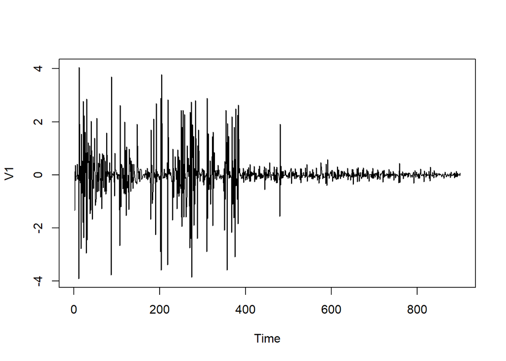

```r
#dane bez trendu
dane_trend<-diff(ts(log(dane2)))
plot(dane_trend)
```

## Periodogram naiwny dla danych bez trendu:

```r
P2<- spec.pgram(dane_trend,log='no', taper=0,pad=0, fast=FALSE,demean=FALSE,detrend=TRUE)
```

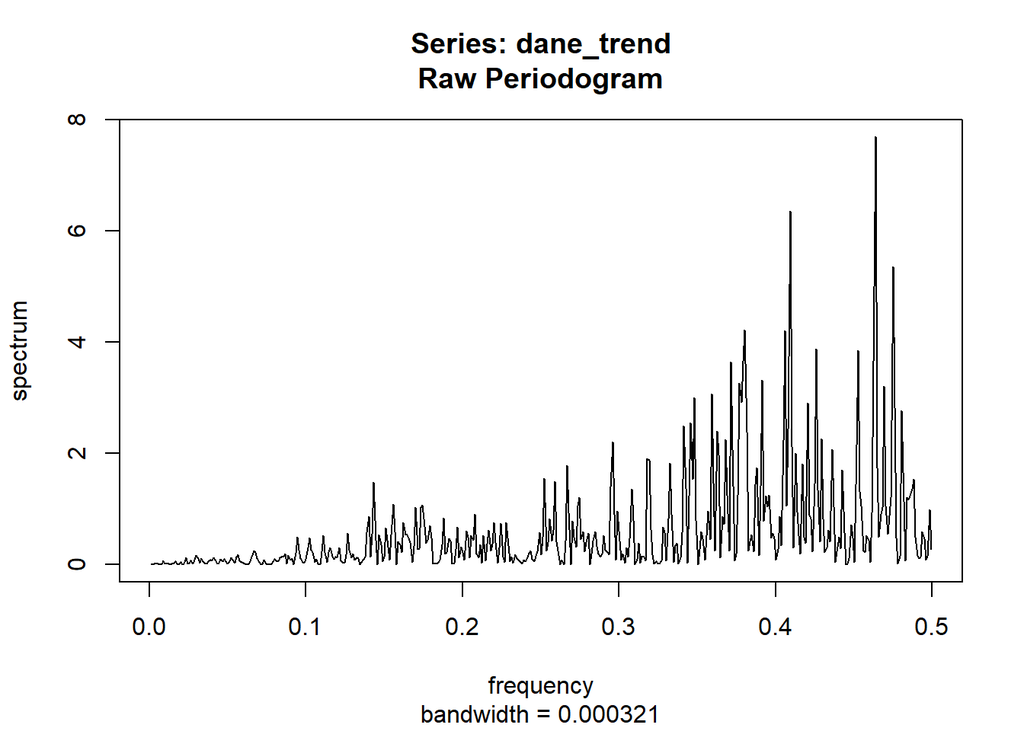

```r
#write.csv(cbind(P2$spec,P2$freq),"sd3.csv")
```

Jak widać powyżej a perdiodogramie, jest wiele “pików”, jednak najbrdziej dominującymi są “pik” dla częstotliwości 0.38, 0.406, 0.409, 0.426, 0.453, 0.464, 0.475. Według nich cykl główny powtarza się co: 1/0.38 = 2,63 miesiąca do 1/0.475 = 2,1 miesiąca. Może to oznaczać, że jest około 2-miesięczna zmiana cyklu.

## Wygładzanie średnią ruchomą

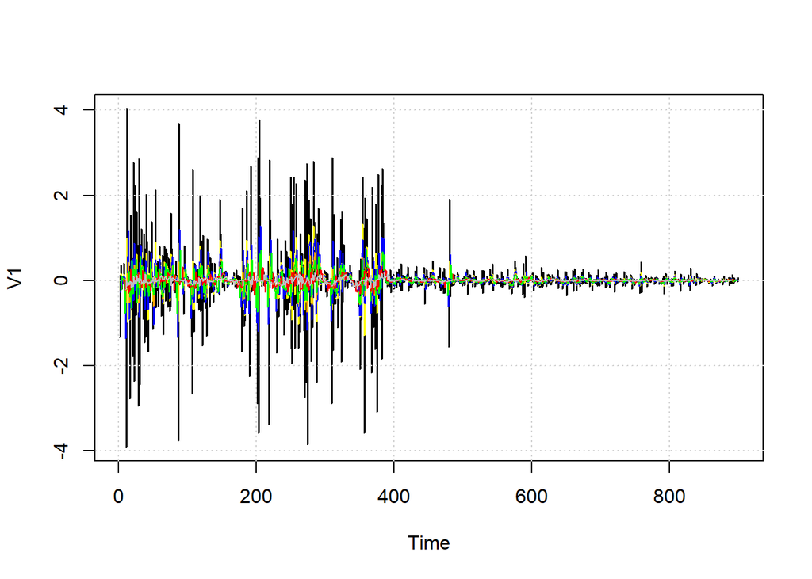

```r
#WYGLADZANIE SREDNIA RUCHOMA:
plot(dane_trend,type="l")
grid()
#wygladzenie srednia ruchoma rzedu 2
f2<-c(1/4,0.5,1/4)
d2 <-filter(dane_trend,f2,sides=2)
lines(d2, col="yellow")
#wygladzenie srednia ruchoma rzedu 3
f3<-c(1/3,1/3,1/3)
d3<-filter(dane_trend,f3,sides=2)
lines(d3, col="blue")
#wygladzenie srednia ruchoma rzedu 4
f4<-c(1/8,1/4,1/4,1/4,1/8)
d4 <-filter(dane_trend,f4,sides=2)
lines(d4, col="orange")
#wygladzenie srednia ruchoma rzedu 5
f5<-c(1/5,1/5,1/5,1/5,1/5)
d5 <-filter(dane_trend,f5,sides=2)
lines(d5, col="green")
#wygladzanie srednia ruchoma rzedu 10
f10<-rep(1/10,10)
d10<-filter(dane2,f10,sides=2)
lines(d10,col="blue")
#wygladzanie srednia ruchoma rzedu 12
f12<-rep(1/12,12)
d12<-filter(dane_trend,f12,sides=2)
lines(d12,col="red")
#wygladzanie srednia ruchoma rzedu 20
f20<-rep(1,20)/20
d20 <- filter(dane_trend,f20,sides=2)
lines(d20, col="grey")
```

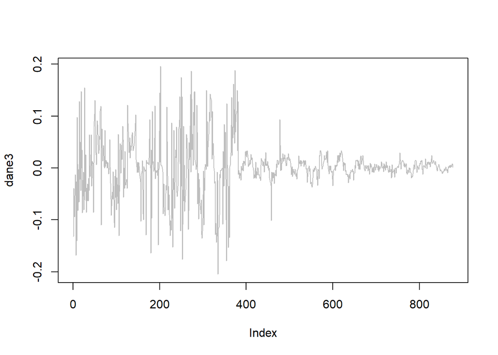

```r
dane3<-d20[12:888]
plot(dane3,type="l",col="grey")
```

Wykres jest najbardziej wygładzony dla lini szarej, kt.óra odpowiada wygładzeniu średnią ruchomą rzędu 20. Jednak należy zwrócić uwagę, że nie ma wielkiej różnicy między wygładzeniem śrdenią rzędu 12, 20 czy 10.

## Periodogramy

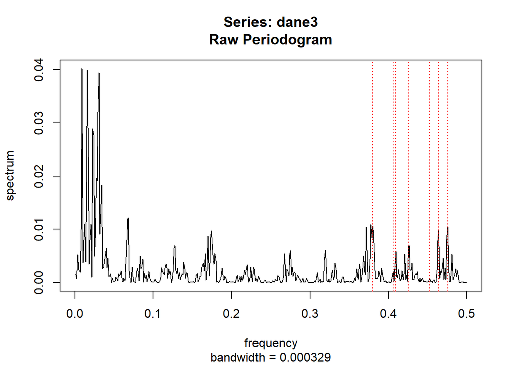

```r
P<- spec.pgram(dane3,log='no', taper=0,pad=0, fast=FALSE,demean=FALSE,detrend=TRUE)
abline(v=0.38,lty='dotted',col="red")
abline(v=0.406,lty='dotted',col="red")
abline(v=0.409,lty='dotted',col="red")
abline(v=0.426,lty='dotted',col="red")
abline(v=0.453,lty='dotted',col="red")
abline(v=0.464,lty='dotted',col="red")
abline(v=0.475,lty='dotted',col="red")
```

Jak widać najwyższe piki są w okolicach 0 - oznaczać to może brak powtarzającego się cyklu głównego.  
**Periodogram wygladzony oknem Daniella**  
Periodogram wygładzony oknem Daniella m=c(2,2) pokazuje przeciwną rzecz, jaką pokazał periodogram naiwny - pokazuje niewielki pik dla częstotliwości 1/12 - czyli przy cyklu corocznym. Również periodogram wygładzony oknem Daniella m=c(2,2) oraz m=3 wykazują pik dla częstotliwości 0.03 (1/0.03 > 2,5 roku).

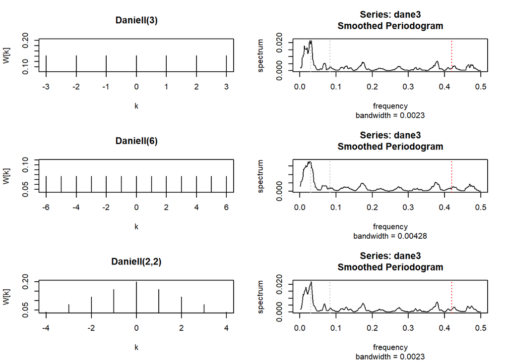

```r
par(mfrow=c(3,2))
window_1<-kernel('daniell',3)
window_2<-kernel('daniell',6)
window_3<-kernel('daniell',c(2,2))
plot(window_1)
P1<-spec.pgram(dane3,kernel=window_1,log='no',taper=0,fast=F,detrend=T)
abline(v=0.42,lty='dotted',col="red")
abline(v=1/12,lty='dotted',col="grey")
abline(v=0.03,lty='dotted',col="grey")
plot(window_2)
spec.pgram(dane3,kernel=window_2,log='no',taper=0,fast=F,detrend=T)

abline(v=0.42,lty='dotted',col="red")
abline(v=1/12,lty='dotted',col="grey")
abline(v=0.03,lty='dotted',col="grey")
plot(window_3)
spec.pgram(dane3,kernel=window_3,log='no',taper=0,fast=F,detrend=T)
abline(v=0.42,lty='dotted',col="red")
abline(v=1/12,lty='dotted',col="grey")
abline(v=0.03,lty='dotted',col="grey")
```

## Odfiltrowanie dominującego sygnału i ponowne wyznaczenie periodogramu

Po odfiltrowaniu dominujacej czestotliwosci rocznej oraz 2,5-letniej i ponownym wyznaczeniu periodogramu, okazało się, że w przedziale <0,1> występuje tylko jedna częstotliwość wynosząca 0. Oznacza ona brak jakkiegokolwiek cyklu.

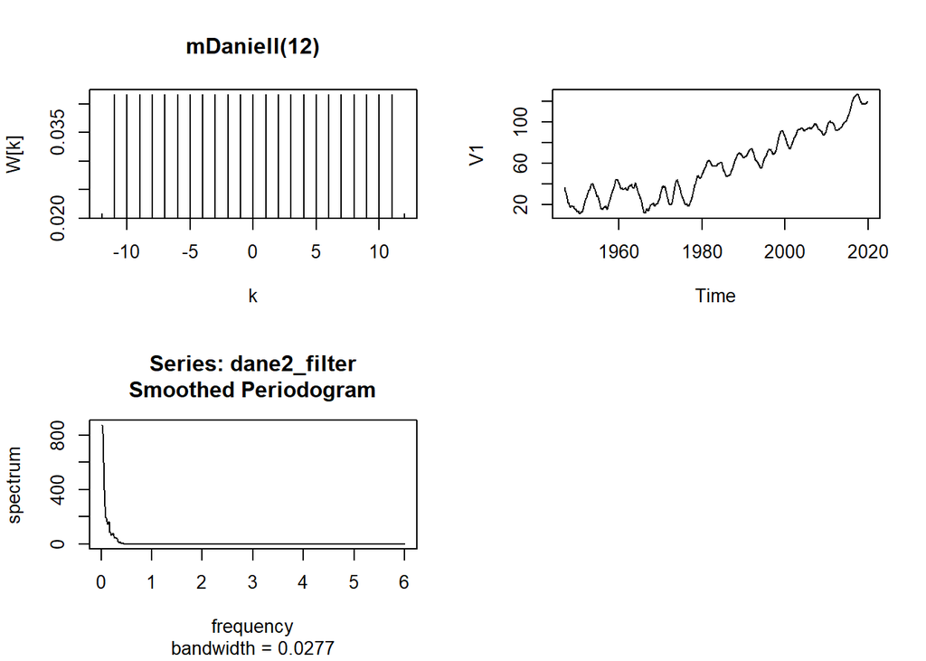

```r
par(mfrow=c(2,2))
k=kernel("modified.daniell",12)
plot(k)
dane2_filter<-kernapply(dane2,k)

#Po odfiltrowaniu:
plot.ts(dane2_filter)

#Periodogram po odfiltrowaniu:
spec.pgram(dane2_filter,kernel('daniell',3),log='no',taper=0,fast=F)
```

## Periodogram Welcha

Najwyższa wartość periodogramu odpowiada częstotliwości 0.

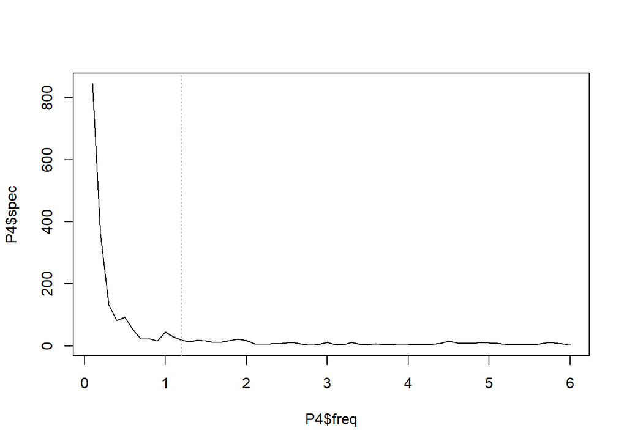

```r
#library(oce)
require(oce)
#PERIODOGRAM WELCHA
danets<-ts(dane,frequency=12)
danets<-danets-mean(danets)
#wykres oeriodogramu welcha wraz z periodogramem naiwnym
P4<-pwelch(dane2,noverlap=10,plot=FALSE)
plot(P4$freq,P4$spec,type="l")
abline(v=1.2,lty='dotted',col="grey")
```

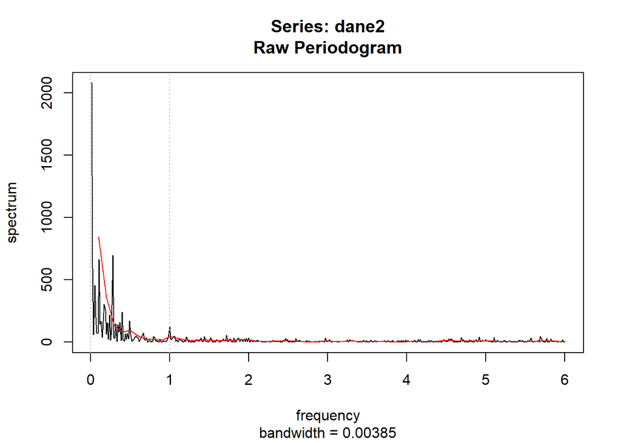

```r
#write.csv(cbind(P4$spec,P4$freq),"sd4.csv")

spec.pgram(dane2,log='no',taper=0,fast=T)
lines(P4$freq,P4$spec,type="l", col="red")
abline(v=1,lty='dotted',col="grey")
abline(v=0,lty='dotted',col="grey")
```

Wykres przedstawia periodogram naiwny oraz periodogram Welcha

## Periodogram MTM

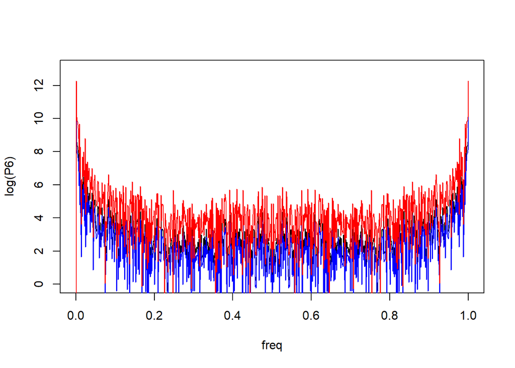

```r
#PERIODOGRAM MTM
require(multitaper)
dane5<-as.ts(read.table("anomalie2.csv"))
freq<-seq(from=0,to=1, length=length(dane5[,1]))
uu<-as.ts(dane5[,1])
uu<-uu-mean(uu)
P6<-abs(fft(uu))^2/(2*pi*length(uu))
L<-qchisq(.2,2)
U<-qchisq(.8,2)
#wyznaczenie przedzialow ufnosci
plot(freq,log(P6),type="l",ylim=c(0,13))
D<-as.matrix(2*P6/L)
G<-as.matrix(2*P6/U)
lines(freq,log(G),type="l",col="blue")
lines(freq,log(D),type="l",col="red")
```

```r
#par(mfrow=c(1,1))
#linie istotnosci dla statystyki F
Spec2<-spec.mtm(dane5,Ftest=TRUE)
```

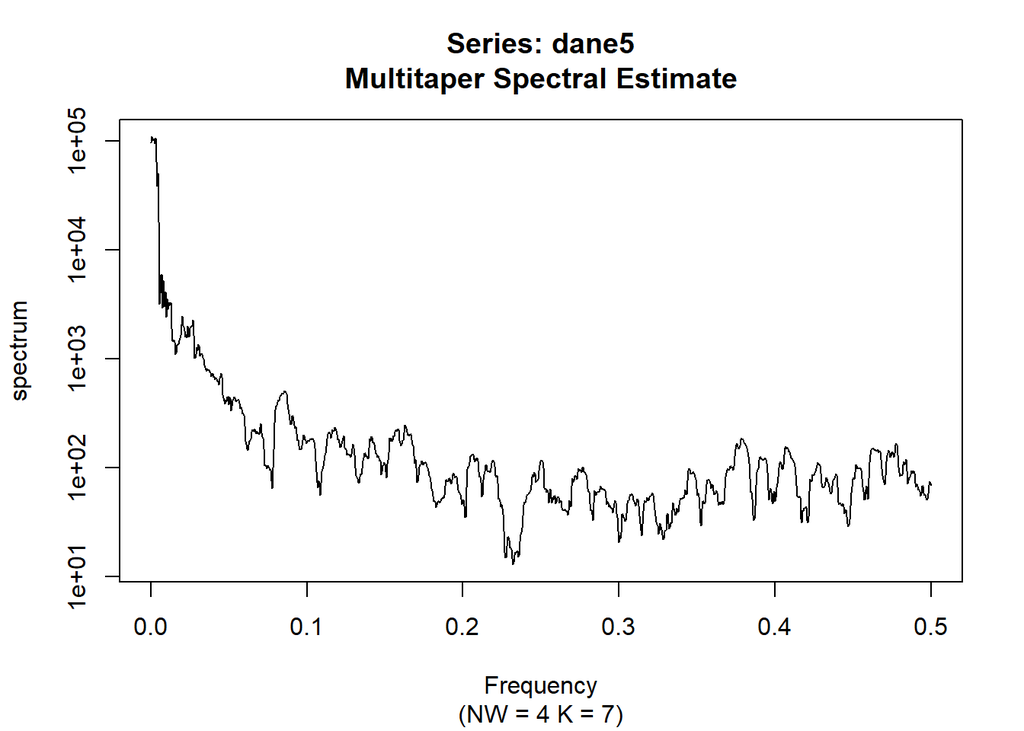

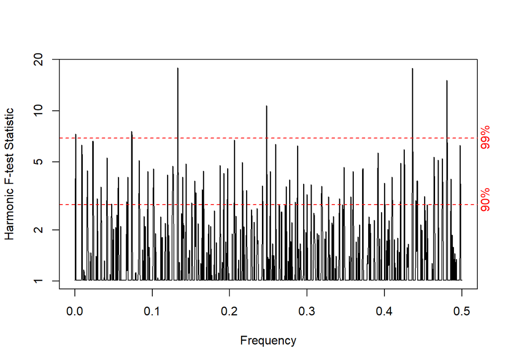

```r
plot(Spec2,Ftest=TRUE,siglines=c(0.90,0.99))
```

```r
#write.csv(cbind(Spec2$mtm$Ftest,Spec2$freq),"sd2.csv")
```

**Na poziomie istotnosci alfa = 0.1** dominuje zbyt wiele częstotliwości

```r
#Przedzial ufnosci
Spec2<-spec.mtm(dane5,Ftest=TRUE,jackknife=TRUE)
```

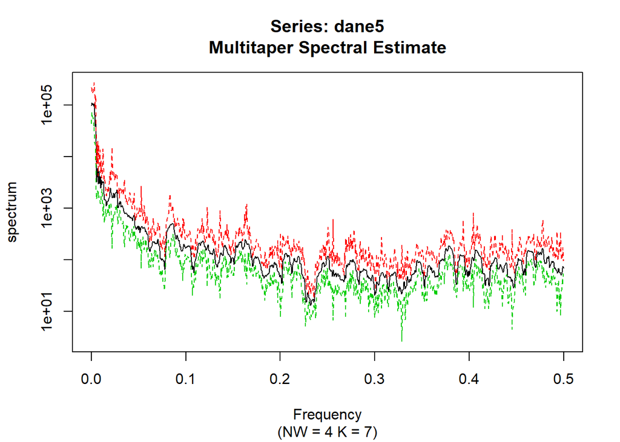